# Optimal Treatment Analysis

## Outcome Variable

**Outcome Variable:** haz

## Predictor Variables

**Intervention Variable:** pers_wast

**Adjustment Set:**

- arm
- sex
- W_mage
- meducyrs
- month
- brthmon
- delta_W_mage
- delta_meducyrs
- delta_month
- delta_brthmon

## Stratifying Variables

The analysis was stratified on these variable(s):

- agecat
- studyid
- country

## Data Summary

| agecat | studyid | country | pers_wast | n_cell | n |
| --- | --- | --- | --- | --- | --- |
| Birth | ki0047075b-MAL-ED | BANGLADESH | 0 | 246 | 255 |
| Birth | ki0047075b-MAL-ED | BANGLADESH | 1 | 9 | 255 |
| Birth | ki0047075b-MAL-ED | BRAZIL | 0 | 191 | 191 |
| Birth | ki0047075b-MAL-ED | BRAZIL | 1 | 0 | 191 |
| Birth | ki0047075b-MAL-ED | INDIA | 0 | 191 | 206 |
| Birth | ki0047075b-MAL-ED | INDIA | 1 | 15 | 206 |
| Birth | ki0047075b-MAL-ED | NEPAL | 0 | 170 | 173 |
| Birth | ki0047075b-MAL-ED | NEPAL | 1 | 3 | 173 |
| Birth | ki0047075b-MAL-ED | PERU | 0 | 286 | 286 |
| Birth | ki0047075b-MAL-ED | PERU | 1 | 0 | 286 |
| Birth | ki0047075b-MAL-ED | SOUTH AFRICA | 0 | 255 | 261 |
| Birth | ki0047075b-MAL-ED | SOUTH AFRICA | 1 | 6 | 261 |
| Birth | ki0047075b-MAL-ED | TANZANIA, UNITED REPUBLIC OF | 0 | 123 | 123 |
| Birth | ki0047075b-MAL-ED | TANZANIA, UNITED REPUBLIC OF | 1 | 0 | 123 |
| Birth | ki1000108-CMC-V-BCS-2002 | INDIA | 0 | 78 | 90 |
| Birth | ki1000108-CMC-V-BCS-2002 | INDIA | 1 | 12 | 90 |
| Birth | ki1000108-IRC | INDIA | 0 | 319 | 388 |
| Birth | ki1000108-IRC | INDIA | 1 | 69 | 388 |
| Birth | ki1000109-EE | PAKISTAN | 0 | 2 | 2 |
| Birth | ki1000109-EE | PAKISTAN | 1 | 0 | 2 |
| Birth | ki1000109-ResPak | PAKISTAN | 0 | 6 | 7 |
| Birth | ki1000109-ResPak | PAKISTAN | 1 | 1 | 7 |
| Birth | ki1101329-Keneba | GAMBIA | 0 | 1507 | 1541 |
| Birth | ki1101329-Keneba | GAMBIA | 1 | 34 | 1541 |
| Birth | ki1114097-CMIN | BANGLADESH | 0 | 5 | 8 |
| Birth | ki1114097-CMIN | BANGLADESH | 1 | 3 | 8 |
| Birth | ki1114097-CMIN | PERU | 0 | 10 | 10 |
| Birth | ki1114097-CMIN | PERU | 1 | 0 | 10 |
| Birth | ki1114097-CONTENT | PERU | 0 | 2 | 2 |
| Birth | ki1114097-CONTENT | PERU | 1 | 0 | 2 |

[output cut: 70 more lines]

The following strata were considered:

- agecat: 24 months, studyid: ki0047075b-MAL-ED, country: BANGLADESH
- agecat: 24 months, studyid: ki0047075b-MAL-ED, country: BRAZIL
- agecat: 24 months, studyid: ki0047075b-MAL-ED, country: INDIA
- agecat: 24 months, studyid: ki0047075b-MAL-ED, country: NEPAL
- agecat: 24 months, studyid: ki0047075b-MAL-ED, country: PERU
- agecat: 24 months, studyid: ki0047075b-MAL-ED, country: SOUTH AFRICA
- agecat: 24 months, studyid: ki0047075b-MAL-ED, country: TANZANIA, UNITED REPUBLIC OF
- agecat: 24 months, studyid: ki1000108-CMC-V-BCS-2002, country: INDIA
- agecat: 24 months, studyid: ki1000108-IRC, country: INDIA
- agecat: 24 months, studyid: ki1017093b-PROVIDE, country: BANGLADESH
- agecat: 24 months, studyid: ki1066203-TanzaniaChild2, country: TANZANIA, UNITED REPUBLIC OF
- agecat: 24 months, studyid: ki1101329-Keneba, country: GAMBIA
- agecat: 24 months, studyid: ki1113344-GMS-Nepal, country: NEPAL
- agecat: 24 months, studyid: ki1114097-CMIN, country: BANGLADESH
- agecat: 24 months, studyid: ki1114097-CMIN, country: PERU
- agecat: 24 months, studyid: ki1114097-CONTENT, country: PERU
- agecat: 6 months, studyid: ki0047075b-MAL-ED, country: BANGLADESH
- agecat: 6 months, studyid: ki0047075b-MAL-ED, country: BRAZIL
- agecat: 6 months, studyid: ki0047075b-MAL-ED, country: INDIA
- agecat: 6 months, studyid: ki0047075b-MAL-ED, country: NEPAL
- agecat: 6 months, studyid: ki0047075b-MAL-ED, country: PERU
- agecat: 6 months, studyid: ki0047075b-MAL-ED, country: SOUTH AFRICA
- agecat: 6 months, studyid: ki0047075b-MAL-ED, country: TANZANIA, UNITED REPUBLIC OF
- agecat: 6 months, studyid: ki1000108-CMC-V-BCS-2002, country: INDIA
- agecat: 6 months, studyid: ki1000108-IRC, country: INDIA
- agecat: 6 months, studyid: ki1000109-EE, country: PAKISTAN
- agecat: 6 months, studyid: ki1000109-ResPak, country: PAKISTAN
- agecat: 6 months, studyid: ki1017093b-PROVIDE, country: BANGLADESH
- agecat: 6 months, studyid: ki1066203-TanzaniaChild2, country: TANZANIA, UNITED REPUBLIC OF
- agecat: 6 months, studyid: ki1101329-Keneba, country: GAMBIA
- agecat: 6 months, studyid: ki1112895-Guatemala BSC, country: GUATEMALA
- agecat: 6 months, studyid: ki1113344-GMS-Nepal, country: NEPAL
- agecat: 6 months, studyid: ki1114097-CMIN, country: BANGLADESH
- agecat: 6 months, studyid: ki1114097-CMIN, country: PERU
- agecat: 6 months, studyid: ki1114097-CONTENT, country: PERU
- agecat: Birth, studyid: ki0047075b-MAL-ED, country: BANGLADESH
- agecat: Birth, studyid: ki0047075b-MAL-ED, country: BRAZIL
- agecat: Birth, studyid: ki0047075b-MAL-ED, country: INDIA
- agecat: Birth, studyid: ki0047075b-MAL-ED, country: NEPAL
- agecat: Birth, studyid: ki0047075b-MAL-ED, country: PERU
- agecat: Birth, studyid: ki0047075b-MAL-ED, country: SOUTH AFRICA
- agecat: Birth, studyid: ki0047075b-MAL-ED, country: TANZANIA, UNITED REPUBLIC OF
- agecat: Birth, studyid: ki1000108-CMC-V-BCS-2002, country: INDIA
- agecat: Birth, studyid: ki1000108-IRC, country: INDIA
- agecat: Birth, studyid: ki1000109-EE, country: PAKISTAN
- agecat: Birth, studyid: ki1000109-ResPak, country: PAKISTAN
- agecat: Birth, studyid: ki1101329-Keneba, country: GAMBIA
- agecat: Birth, studyid: ki1114097-CMIN, country: BANGLADESH
- agecat: Birth, studyid: ki1114097-CMIN, country: PERU
- agecat: Birth, studyid: ki1114097-CONTENT, country: PERU

### Dropped Strata

Some strata were dropped due to rare outcomes:

- agecat: Birth, studyid: ki0047075b-MAL-ED, country: BRAZIL
- agecat: Birth, studyid: ki0047075b-MAL-ED, country: NEPAL
- agecat: Birth, studyid: ki0047075b-MAL-ED, country: PERU
- agecat: Birth, studyid: ki0047075b-MAL-ED, country: TANZANIA, UNITED REPUBLIC OF
- agecat: Birth, studyid: ki1000109-EE, country: PAKISTAN
- agecat: Birth, studyid: ki1000109-ResPak, country: PAKISTAN
- agecat: Birth, studyid: ki1114097-CMIN, country: BANGLADESH
- agecat: Birth, studyid: ki1114097-CMIN, country: PERU
- agecat: Birth, studyid: ki1114097-CONTENT, country: PERU
- agecat: 6 months, studyid: ki0047075b-MAL-ED, country: BRAZIL
- agecat: 6 months, studyid: ki0047075b-MAL-ED, country: NEPAL
- agecat: 6 months, studyid: ki0047075b-MAL-ED, country: PERU
- agecat: 6 months, studyid: ki0047075b-MAL-ED, country: SOUTH AFRICA
- agecat: 6 months, studyid: ki0047075b-MAL-ED, country: TANZANIA, UNITED REPUBLIC OF
- agecat: 6 months, studyid: ki1114097-CONTENT, country: PERU
- agecat: 24 months, studyid: ki0047075b-MAL-ED, country: BRAZIL
- agecat: 24 months, studyid: ki0047075b-MAL-ED, country: NEPAL
- agecat: 24 months, studyid: ki0047075b-MAL-ED, country: PERU
- agecat: 24 months, studyid: ki0047075b-MAL-ED, country: SOUTH AFRICA
- agecat: 24 months, studyid: ki0047075b-MAL-ED, country: TANZANIA, UNITED REPUBLIC OF
- agecat: 24 months, studyid: ki1066203-TanzaniaChild2, country: TANZANIA, UNITED REPUBLIC OF
- agecat: 24 months, studyid: ki1114097-CONTENT, country: PERU

## Methods Detail

We’re interested in the causal parameters $E[Y_a]$ for all values of $a \in \mathcal{A}$. These parameters represent the mean outcome if, possibly contrary to fact, we intervened to set all units to have $A=a$. Under the randomization and positivity assumptions, these are identified by the statistical parameters $\psi_a=E_W[E_{Y|A,W}(Y|A=a,W)]$. In addition, we’re interested in the mean of $Y$, $E[Y]$ under no intervention (the observed mean). We will estimate these parameters by using SuperLearner to fit the relevant likelihood factors – $E_{Y|A,W}(Y|A=a,W)$ and $p(A=a|W)$, and then updating our likelihood fit using a joint TMLE.

For unadjusted analyses ($W=\{\}$), initial likelihoods were estimated using Lrnr_glm to estimate the simple $E(Y|A)$ and Lrnr_mean to estimate $p(A)$. For adjusted analyses, a small library containing Lrnr_glmnet, Lrnr_xgboost, and Lrnr_mean was used.

# Results Detail

## Results Plots

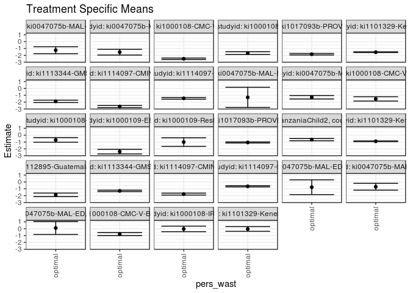

## Results Table

### Parameter: TSM

| agecat | studyid | country | intervention_level | baseline_level | estimate | ci_lower | ci_upper |
| --- | --- | --- | --- | --- | --- | --- | --- |
| Birth | ki0047075b-MAL-ED | BANGLADESH | optimal | observed | -0.7685954 | -1.8422287 | 0.3050380 |
| Birth | ki0047075b-MAL-ED | INDIA | optimal | observed | -0.6970959 | -1.1923681 | -0.2018237 |
| Birth | ki0047075b-MAL-ED | SOUTH AFRICA | optimal | observed | 0.1018299 | -0.8373715 | 1.0410313 |
| Birth | ki1000108-CMC-V-BCS-2002 | INDIA | optimal | observed | -0.7775033 | -0.9942317 | -0.5607749 |
| Birth | ki1000108-IRC | INDIA | optimal | observed | -0.0292945 | -0.4337739 | 0.3751849 |
| Birth | ki1101329-Keneba | GAMBIA | optimal | observed | -0.0358652 | -0.3754910 | 0.3037606 |
| 6 months | ki0047075b-MAL-ED | BANGLADESH | optimal | observed | -1.3074092 | -2.7805529 | 0.1657346 |
| 6 months | ki0047075b-MAL-ED | INDIA | optimal | observed | -1.2945751 | -1.5466194 | -1.0425309 |
| 6 months | ki1000108-CMC-V-BCS-2002 | INDIA | optimal | observed | -1.5306482 | -1.8440707 | -1.2172256 |
| 6 months | ki1000108-IRC | INDIA | optimal | observed | -0.6957148 | -1.0317033 | -0.3597263 |
| 6 months | ki1000109-EE | PAKISTAN | optimal | observed | -2.3987127 | -2.7361391 | -2.0612863 |
| 6 months | ki1000109-ResPak | PAKISTAN | optimal | observed | -1.0066450 | -1.6366108 | -0.3766791 |
| 6 months | ki1017093b-PROVIDE | BANGLADESH | optimal | observed | -1.0641482 | -1.1405114 | -0.9877849 |
| 6 months | ki1066203-TanzaniaChild2 | TANZANIA, UNITED REPUBLIC OF | optimal | observed | -0.6430039 | -0.8149407 | -0.4710672 |
| 6 months | ki1101329-Keneba | GAMBIA | optimal | observed | -0.8896935 | -0.9368241 | -0.8425630 |
| 6 months | ki1112895-Guatemala BSC | GUATEMALA | optimal | observed | -1.8787241 | -2.1354029 | -1.6220452 |
| 6 months | ki1113344-GMS-Nepal | NEPAL | optimal | observed | -1.3035968 | -1.4096998 | -1.1974938 |
| 6 months | ki1114097-CMIN | BANGLADESH | optimal | observed | -1.7719363 | -1.9136466 | -1.6302261 |
| 6 months | ki1114097-CMIN | PERU | optimal | observed | -0.6431275 | -0.7299847 | -0.5562704 |
| 24 months | ki0047075b-MAL-ED | BANGLADESH | optimal | observed | -1.2554320 | -1.7643154 | -0.7465486 |
| 24 months | ki0047075b-MAL-ED | INDIA | optimal | observed | -1.5367608 | -1.9587779 | -1.1147438 |
| 24 months | ki1000108-CMC-V-BCS-2002 | INDIA | optimal | observed | -2.5036488 | -2.6107732 | -2.3965243 |
| 24 months | ki1000108-IRC | INDIA | optimal | observed | -1.6732020 | -1.8797809 | -1.4666232 |
| 24 months | ki1017093b-PROVIDE | BANGLADESH | optimal | observed | -1.8330960 | -1.9476271 | -1.7185648 |
| 24 months | ki1101329-Keneba | GAMBIA | optimal | observed | -1.5413137 | -1.5939079 | -1.4887195 |
| 24 months | ki1113344-GMS-Nepal | NEPAL | optimal | observed | -1.8857887 | -2.0558813 | -1.7156961 |
| 24 months | ki1114097-CMIN | BANGLADESH | optimal | observed | -2.6434190 | -2.8109998 | -2.4758383 |
| 24 months | ki1114097-CMIN | PERU | optimal | observed | -1.4457589 | -1.5704845 | -1.3210332 |

### Parameter: E(Y)

| agecat | studyid | country | intervention_level | baseline_level | estimate | ci_lower | ci_upper |
| --- | --- | --- | --- | --- | --- | --- | --- |
| Birth | ki0047075b-MAL-ED | BANGLADESH | observed | observed | -1.0715686 | -1.1969582 | -0.9461791 |
| Birth | ki0047075b-MAL-ED | INDIA | observed | observed | -1.0106311 | -1.1499962 | -0.8712660 |
| Birth | ki0047075b-MAL-ED | SOUTH AFRICA | observed | observed | -0.7064368 | -0.8290380 | -0.5838355 |
| Birth | ki1000108-CMC-V-BCS-2002 | INDIA | observed | observed | -0.9654444 | -1.1742112 | -0.7566777 |
| Birth | ki1000108-IRC | INDIA | observed | observed | -0.3080412 | -0.4687931 | -0.1472894 |
| Birth | ki1101329-Keneba | GAMBIA | observed | observed | 0.0341467 | -0.0293905 | 0.0976838 |
| 6 months | ki0047075b-MAL-ED | BANGLADESH | observed | observed | -1.2056777 | -1.3231497 | -1.0882058 |
| 6 months | ki0047075b-MAL-ED | INDIA | observed | observed | -1.2203672 | -1.3387619 | -1.1019726 |
| 6 months | ki1000108-CMC-V-BCS-2002 | INDIA | observed | observed | -1.4251321 | -1.5673802 | -1.2828839 |
| 6 months | ki1000108-IRC | INDIA | observed | observed | -1.2344062 | -1.3658524 | -1.1029600 |
| 6 months | ki1000109-EE | PAKISTAN | observed | observed | -2.2004704 | -2.3234073 | -2.0775336 |
| 6 months | ki1000109-ResPak | PAKISTAN | observed | observed | -1.4029220 | -1.6085859 | -1.1972581 |
| 6 months | ki1017093b-PROVIDE | BANGLADESH | observed | observed | -1.0871041 | -1.1635539 | -1.0106543 |
| 6 months | ki1066203-TanzaniaChild2 | TANZANIA, UNITED REPUBLIC OF | observed | observed | -0.5434389 | -0.5924056 | -0.4944722 |
| 6 months | ki1101329-Keneba | GAMBIA | observed | observed | -0.9121372 | -0.9593127 | -0.8649617 |
| 6 months | ki1112895-Guatemala BSC | GUATEMALA | observed | observed | -1.5785476 | -1.6926664 | -1.4644288 |
| 6 months | ki1113344-GMS-Nepal | NEPAL | observed | observed | -1.3321522 | -1.4103691 | -1.2539352 |
| 6 months | ki1114097-CMIN | BANGLADESH | observed | observed | -1.7844376 | -1.9222926 | -1.6465825 |
| 6 months | ki1114097-CMIN | PERU | observed | observed | -0.5098299 | -0.5892202 | -0.4304395 |
| 24 months | ki0047075b-MAL-ED | BANGLADESH | observed | observed | -1.9431132 | -2.0691678 | -1.8170586 |
| 24 months | ki0047075b-MAL-ED | INDIA | observed | observed | -1.8458150 | -1.9718703 | -1.7197596 |
| 24 months | ki1000108-CMC-V-BCS-2002 | INDIA | observed | observed | -2.5530299 | -2.6529925 | -2.4530672 |
| 24 months | ki1000108-IRC | INDIA | observed | observed | -1.7824776 | -1.8765600 | -1.6883952 |
| 24 months | ki1017093b-PROVIDE | BANGLADESH | observed | observed | -1.5861179 | -1.6693668 | -1.5028689 |
| 24 months | ki1101329-Keneba | GAMBIA | observed | observed | -1.5604961 | -1.6126979 | -1.5082943 |
| 24 months | ki1113344-GMS-Nepal | NEPAL | observed | observed | -1.8835905 | -1.9681499 | -1.7990312 |
| 24 months | ki1114097-CMIN | BANGLADESH | observed | observed | -2.5109504 | -2.6361514 | -2.3857494 |
| 24 months | ki1114097-CMIN | PERU | observed | observed | -1.4696439 | -1.5956384 | -1.3436493 |

### Parameter: PAR

| agecat | studyid | country | intervention_level | baseline_level | estimate | ci_lower | ci_upper |
| --- | --- | --- | --- | --- | --- | --- | --- |
| Birth | ki0047075b-MAL-ED | BANGLADESH | optimal | observed | -0.3029733 | -1.3518545 | 0.7459079 |
| Birth | ki0047075b-MAL-ED | INDIA | optimal | observed | -0.3135352 | -0.7930764 | 0.1660061 |
| Birth | ki0047075b-MAL-ED | SOUTH AFRICA | optimal | observed | -0.8082667 | -1.7338783 | 0.1173449 |
| Birth | ki1000108-CMC-V-BCS-2002 | INDIA | optimal | observed | -0.1879411 | -0.3512575 | -0.0246247 |
| Birth | ki1000108-IRC | INDIA | optimal | observed | -0.2787467 | -0.6409031 | 0.0834097 |
| Birth | ki1101329-Keneba | GAMBIA | optimal | observed | 0.0700119 | -0.2589107 | 0.3989344 |
| 6 months | ki0047075b-MAL-ED | BANGLADESH | optimal | observed | 0.1017314 | -1.3385712 | 1.5420341 |
| 6 months | ki0047075b-MAL-ED | INDIA | optimal | observed | 0.0742079 | -0.1672034 | 0.3156192 |
| 6 months | ki1000108-CMC-V-BCS-2002 | INDIA | optimal | observed | 0.1055161 | -0.1852933 | 0.3963255 |
| 6 months | ki1000108-IRC | INDIA | optimal | observed | -0.5386914 | -0.8414363 | -0.2359465 |
| 6 months | ki1000109-EE | PAKISTAN | optimal | observed | 0.1982423 | -0.1082702 | 0.5047547 |
| 6 months | ki1000109-ResPak | PAKISTAN | optimal | observed | -0.3962770 | -0.9865660 | 0.1940120 |
| 6 months | ki1017093b-PROVIDE | BANGLADESH | optimal | observed | -0.0229559 | -0.0420525 | -0.0038593 |
| 6 months | ki1066203-TanzaniaChild2 | TANZANIA, UNITED REPUBLIC OF | optimal | observed | 0.0995650 | -0.0649398 | 0.2640698 |
| 6 months | ki1101329-Keneba | GAMBIA | optimal | observed | -0.0224437 | -0.0335326 | -0.0113547 |
| 6 months | ki1112895-Guatemala BSC | GUATEMALA | optimal | observed | 0.3001765 | 0.0566146 | 0.5437383 |
| 6 months | ki1113344-GMS-Nepal | NEPAL | optimal | observed | -0.0285553 | -0.1184995 | 0.0613889 |
| 6 months | ki1114097-CMIN | BANGLADESH | optimal | observed | -0.0125012 | -0.0401654 | 0.0151629 |
| 6 months | ki1114097-CMIN | PERU | optimal | observed | 0.1332977 | 0.0779948 | 0.1886005 |
| 24 months | ki0047075b-MAL-ED | BANGLADESH | optimal | observed | -0.6876812 | -1.2005094 | -0.1748530 |
| 24 months | ki0047075b-MAL-ED | INDIA | optimal | observed | -0.3090542 | -0.7192708 | 0.1011625 |
| 24 months | ki1000108-CMC-V-BCS-2002 | INDIA | optimal | observed | -0.0493811 | -0.0934834 | -0.0052789 |
| 24 months | ki1000108-IRC | INDIA | optimal | observed | -0.1092756 | -0.3030642 | 0.0845131 |
| 24 months | ki1017093b-PROVIDE | BANGLADESH | optimal | observed | 0.2469781 | 0.1341603 | 0.3597959 |
| 24 months | ki1101329-Keneba | GAMBIA | optimal | observed | -0.0191823 | -0.0305603 | -0.0078044 |
| 24 months | ki1113344-GMS-Nepal | NEPAL | optimal | observed | 0.0021982 | -0.1381371 | 0.1425335 |
| 24 months | ki1114097-CMIN | BANGLADESH | optimal | observed | 0.1324686 | 0.0171752 | 0.2477620 |
| 24 months | ki1114097-CMIN | PERU | optimal | observed | -0.0238850 | -0.0576820 | 0.0099120 |